# INST0065 Assessmwent 2

20054130

23/03/2021

# INST005 Assessment 2

Word Count: 1613

## Data

The data for this markdown file are taken from https://rebrickable.com/downloads/

# Introduction

The datasets come from the Lego website https://rebrickable.com/downloads/. The website provides a Lego database that contains data about official Lego items, including Sets, Parts, and Minifigs, and information like colours and themes. These data are stored in 8 datasets and can be accessed through CSV files download or API.

The relationship mapping between datasets are as follows: id (colors) -> color_id (inventory_Parts) id (colors) -> color_id (elements) id (inventories) -> inventory_id (inventory_parts) part_num (parts) -> part_num (inventory_parts) id (part_categories) -> part_cat_id (parts) id(themes) -> theme_id(sets) set_num(inventory_sets) -> set_num(sets) fig_num(inventory_minifigs) -> fig_num(minifigs)

This mapping is important for joining tables later.

The datasets I will use are ‘sets’, ‘themes’, ‘inventory_parts’ and ‘colors’. I am going to explore the change of size of Lego sets, popular themes in recent 20 years and popular parts’ colours with them.

# Method

## Data preparation

In this section, required datasets were imported and modified to make them available in the right format for data visualizations. Firstly, I joined ‘sets’ and ‘themes’ datasets to present all related information about sets and themes so that I can refer to themes by their names which are more identifiable than ID numbers. Before joined these two tables, I noticed that the ‘themes’ table refers to itself by the column ‘parent_id’. This implies information about sub-themes, so I also merged the ‘themes’ table with itself. Then it brought about duplicate column names, so I renamed these columns. For a better understanding about the column ‘parent_id.y’, which represents the parent of the parent of theme, I change the name to ‘grandparent_id’.

```r
themes <- merge(themes,themes,by.x="parent_id",by.y="id",all.x = TRUE) # self-merge themes table
colnames(themes)[3] <- 'name' # rename the column 'name.x'
colnames(themes)[4] <- 'parent_name' # rename the column 'name.y'
colnames(themes)[5] <- 'grandparent_id' # rename the column 'parent_id.y'
```

For some themes which are in the upper level, their parent names are ‘NA’. This makes no senses if I would like to look at a theme and its sub-theme. To solve this problem, I refilled these void values with the name of their sub-themes.

```r
themes$parent_name[is.na(themes$parent_name)] <- themes$name[is.na(themes$parent_name)]
```

Then I joined the new themes table with sets table.

```r
sets <- merge(sets,themes,by.x = "theme_id",by.y = "id",all.x = TRUE)
```

Similar to the merge of themes table, I renamed columns for the duplicate names.

```r
colnames(sets)[3] <- 'set_name';
colnames(sets)[7] <- 'name';
```

The new ‘sets’ table looks like this:

```r
head(sets)
```

```
##   theme_id set_num                   set_name year num_parts parent_id    name
## 1        1   001-1                      Gears 1965        43        NA Technic
## 2        1  9853-1        Assortment of Gears 1992       122        NA Technic
## 3        1  9854-1             Worm Gear Pack 1992        22        NA Technic
## 4        1  9855-1 Assortment of Tires/Wheels 1992        56        NA Technic
## 5        1  9856-1  Assortment of Cross Axles 1992       124        NA Technic
## 6        1  9857-1 Assortment of Plate Pieces 1992       166        NA Technic
##   parent_name grandparent_id
## 1     Technic             NA
## 2     Technic             NA
## 3     Technic             NA
## 4     Technic             NA
## 5     Technic             NA
## 6     Technic             NA
```

I created a new data frame ‘s’ to store the average number of parts in Lego sets based on ‘set’ so that I could plot the change of the average number of parts over the past 71 years and see the trend.

```r
s <- sets %>%
arrange(year) %>%
group_by(year) %>%
summarise(num_parts=mean(num_parts))
count_sets <- count(sets, var = year)
```

Next I would like to see the most popular themes in the 21st century, so I filtered the original dataset and count the frequency of theme.

```r
t <- sets %>%
filter(year >= 2000)
```

```r
count_of_theme <- count(t,var=parent_name)
```

To see top 5 popular themes’ yearly distribution in number of sets in recent 20 years, I selected these popular themes’ data and assigned them to a new vector ‘p’.

```r
p <- t %>%
  filter(parent_name %in% c("Gear","Star Wars", "Collectible Minifigures", "Duplo", "City"))
```

```r
head(p)
```

```
##   theme_id set_num                    set_name year num_parts parent_id    name
## 1       53 66156-1 City Airport Exclusive Pack 2006         0        52 Airport
## 2       53 60021-1             Cargo Heliplane 2013       393        52 Airport
## 3       53 60260-1                    Air Race 2020       140        52 Airport
## 4       53 60144-1                  Race Plane 2017        89        52 Airport
## 5       53 60061-1          Airport Fire Truck 2014       326        52 Airport
## 6       53  7696-1                Commuter Jet 2011       108        52 Airport
##   parent_name grandparent_id
## 1        City             50
## 2        City             50
## 3        City             50
## 4        City             50
## 5        City             50
## 6        City             50
```

Then, I used the same way to merge the ‘inventory_parts’ and ‘color’ datasets because I would use them to plot a bar chart about the number of parts in each colour and see the most popular colours of parts.

```r
inventory_parts <- merge(inventory_parts, colors, by.x = "color_id", by.y = "id",all.x = TRUE)
```

The new ‘inventory_parts’ table looks like this:

```r
head(inventory_parts)
```

```
##   color_id inventory_id        part_num quantity is_spare      name    rgb
## 1       -1        27705            3437        4    FALSE [Unknown] 0033B2
## 2       -1        40244           1051A        1    FALSE [Unknown] 0033B2
## 3       -1        66521 973c28h01pr9669        1    FALSE [Unknown] 0033B2
## 4       -1         4365         65535g1        1    FALSE [Unknown] 0033B2
## 5       -1        40244           1022B        1    FALSE [Unknown] 0033B2
## 6       -1        40242       mxupn0003        1    FALSE [Unknown] 0033B2
##   is_trans
## 1    FALSE
## 2    FALSE
## 3    FALSE
## 4    FALSE
## 5    FALSE
## 6    FALSE
```

# Data Visualization

Next, to see the most popular themes of Lego sets in the new century, I produced a bar chart about the sum of sets under each theme between 2000 and 2021 in descending order. There is a problem that the size of themes is too large. There are 136 kinds of themes. This will cause the labels on the x-axis too crowded and make it hard to see the texts clearly, so I only presented those whose counts ranked in the top 25%. After that, I would like to see how the distribution of these top 5 popular themes change over the recent 20 years, so I plotted a bar chart about the number of sets and year, filled with the top 5 popular themes.

Finally, I took a look at what are the most popular colours of parts. I used the same way as plotting themes to plot the bar chart about colours and their frequencies. As the ‘color’ table does not have a common key that is related to the released years, so I was not able to analyze the change of colours over years.

# Results

The first visualization is a scatter plot about the change of the number of parts in Lego sets over years. Each point represents the number of parts contained in each Lego set. It shows that the size of sets is generally increasing, and most of the points mainly distribute under the value of 2000 parts. After 2010, the number of sets with more than 2000 parts is getting bigger. Some sets even have more than 7500 parts.

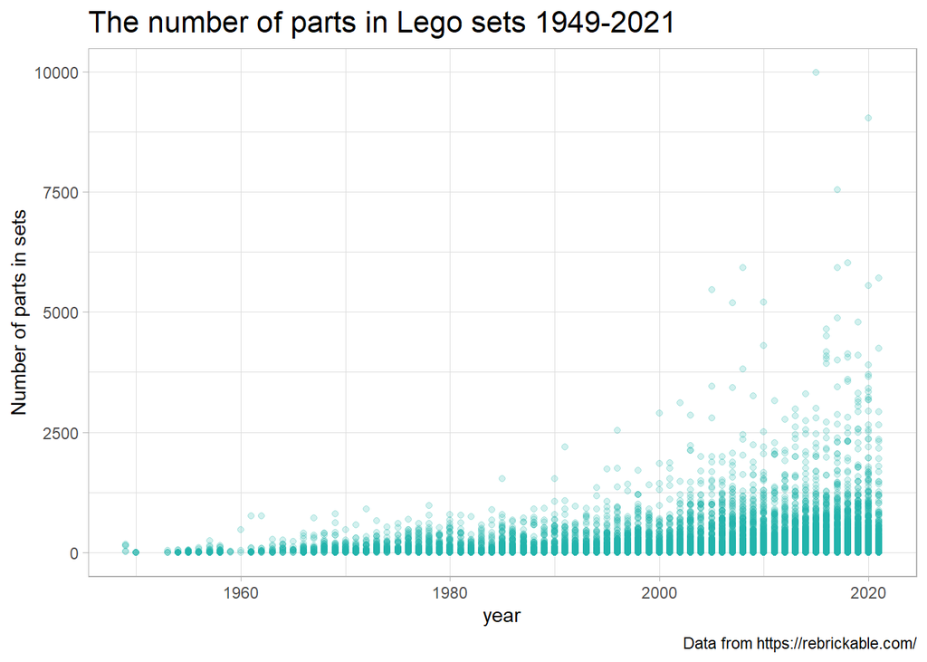

```r
plot1 <- ggplot(sets,aes(x=year,y=num_parts))+
  geom_point(alpha = 0.2, colour = "lightseagreen")+
  labs(x = "year", y = "Number of parts in sets", title = "The number of parts in Lego sets 1949-2021", caption = "Data from https://rebrickable.com/") +
  theme_light() +
  theme(plot.title = element_text(size=16))
plot1
```

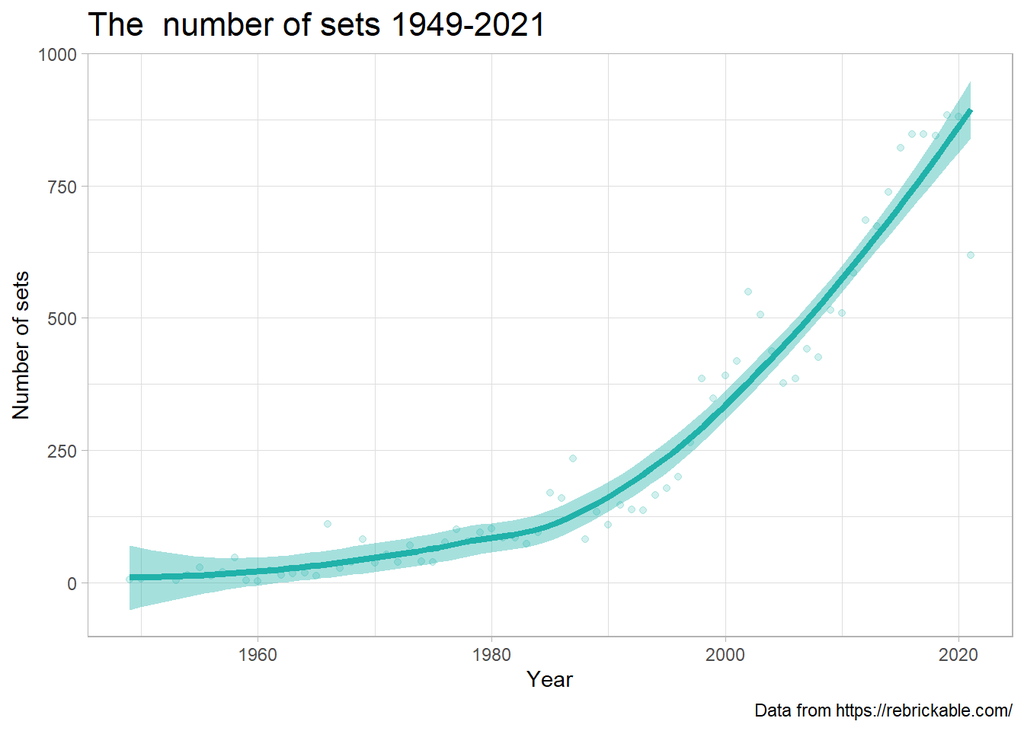

```r
plot_sets <- ggplot(count_sets,aes(x=var,y=n)) +
  geom_smooth(method = "loess", size = 1.5, colour = "lightseagreen", fill = "lightseagreen") +
  geom_point(alpha = 0.2, colour = "lightseagreen") +
  labs(x = "Year", y = "Number of sets", title = "The  number of sets 1949-2021",caption = "Data from https://rebrickable.com/") +
  theme_light() +
  theme(plot.title = element_text(size=16))
plot_sets
```

Next, it is also a line graph which is about the average number of parts contained in each Lego set between 1949 and 2021. From it, we can see that the sets are growing bigger year by year. From 1980 to 2000, the size of each set maintained at 100 parts approximately and then continued to grow to 200 parts by 2020.

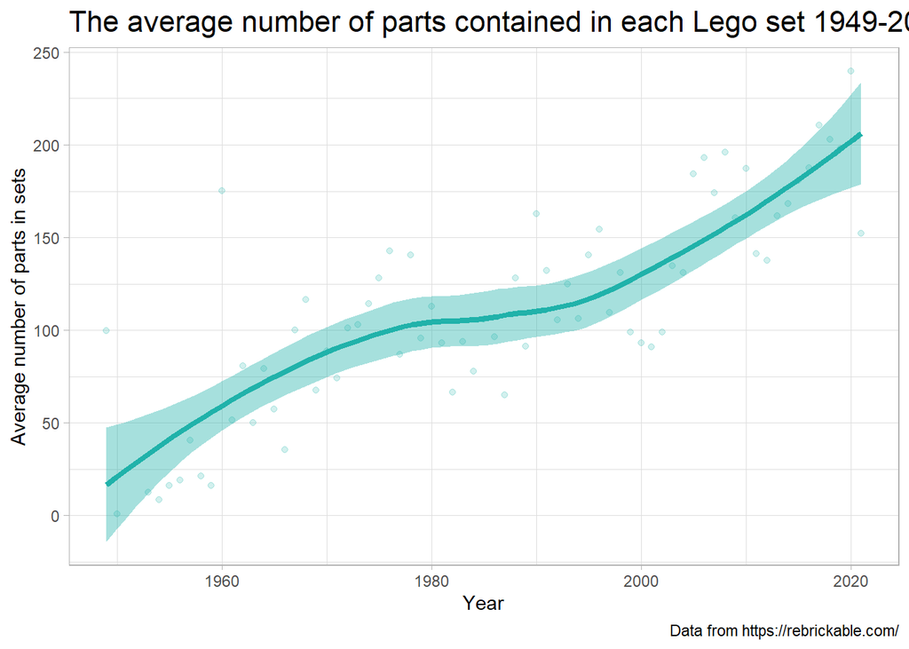

```r
plot2 <-ggplot(s, aes(x = year, y = num_parts)) +
geom_smooth(method = "loess", size = 1.5, colour = "lightseagreen", fill = "lightseagreen") +
geom_point(alpha = 0.2, colour = "lightseagreen")+
labs(x = "Year", y = "Average number of parts in sets", title = "The average number of parts contained in each Lego set 1949-2021",caption = "Data from https://rebrickable.com/")+
theme_light()+
theme(plot.title = element_text(size=16))

plot2
```

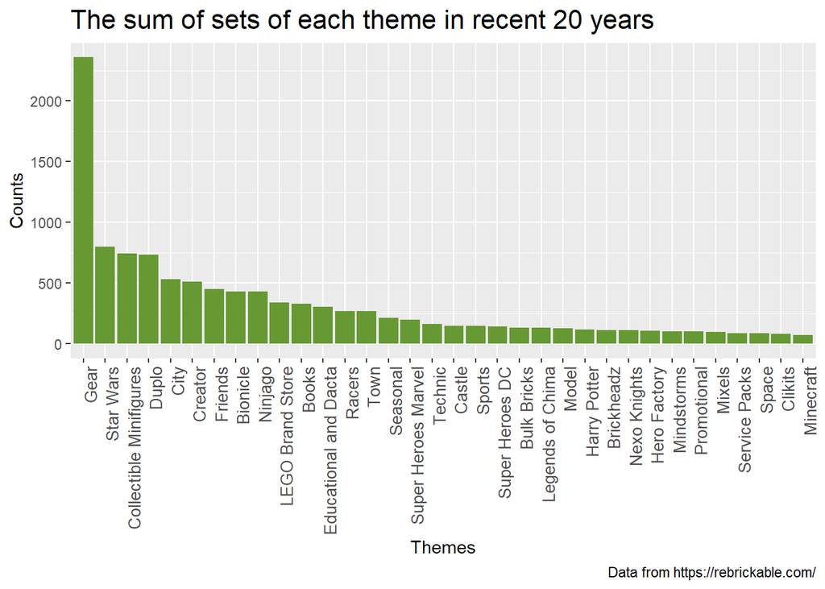

```r
plot_theme <- ggplot(count_of_theme[count_of_theme$n>unname(quantile(count_of_theme$n,0.75)),],aes(x=reorder(var,-n),y=n))+geom_col(fill = "#669933") +
  theme(axis.text.x=element_text(angle=90,size = 10,hjust = 1),plot.title = element_text(size=16)) +
  labs(x = "Themes", y = "Counts", title = "The sum of sets of each theme in recent 20 years",caption = "Data from https://rebrickable.com/")

plot_theme
```

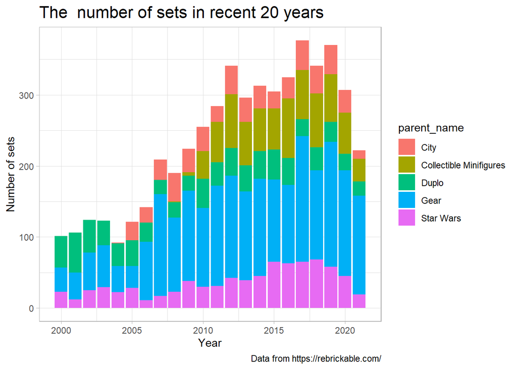

```r
plot4 <- ggplot(data = p) +
  geom_bar(mapping=aes(x=year, fill=parent_name)) +
  labs(x = "Year", y = "Number of sets", title = "The  number of sets in recent 20 years",caption = "Data from https://rebrickable.com/")+
  theme_light()+
  theme(plot.title = element_text(size=16))
plot4
```

The last visualization is a bar chart showing the frequency of parts’ colours in descending order. From the chart, we can see that the most commonly used 5 colours in the past 71 years are Black, White, Light Bluish Gray, Red, and Dark Bluish Gray. There are 175 kinds of colours, but only a small number of them are often used. The remainder of the parts consists of a growing long tail of many minor colours.

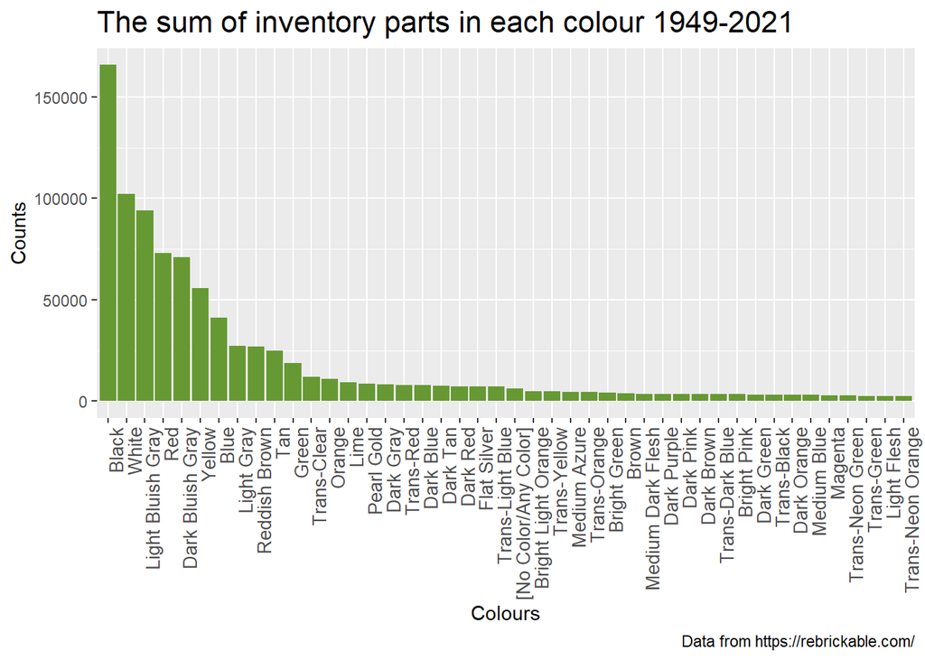

```r
plot_colour <- ggplot(count_color[count_color$n>unname(quantile(count_color$n,0.75)),],aes(x=reorder(var,-n),y=n)) +
  geom_col(fill = "#669933") +
  theme(axis.text.x=element_text(angle=90,size = 10,hjust = 1),plot.title = element_text(size=16)) +
  labs(x = "Colours", y = "Counts", title = "The sum of inventory parts in each colour 1949-2021",caption = "Data from https://rebrickable.com/")

plot_colour
```

# Conclusion

1 The size of Lego sets is bigger now than it used to be, and there have been several super large-scale sets in recent years.

2 The number of sets grows dramatically after 1990 and it is predicted to grow in the future. The average number of parts contained in each set also increase from 30 parts to 200 parts over the past 71 years.

3 Lego covers various kinds of themes, but only a few of them are very popular. The most popular themes in recent 20 years are Gear, Star Wars, Collectible Minifigures, Duplo and City. These popular themes went through slightly changing for the distribution, such as Gear grows to be the most popular theme after 2005 and Duplo, which used to be the most popular one in 2000, reduced to the least popular theme among these 5 themes.

4 Similarly, Lego parts have a large colour palette, but only 5 of them are the most commonly used colours. They are Black, White, Light Bluish Gray, Red, and Dark Bluish Gray.

Apart from the 6 graphs I created, many other visualizations could be useful to produce. For example, using the ‘part_category’ table and ‘parts’ table to produce a scatter plot to see what category contains the most parts, or merging the table ‘element’ with ‘colors’ to see what are popular colours in elements.